# Analysis of 2019 Boston Marathon

## Top 25 Countries - Other than the USA

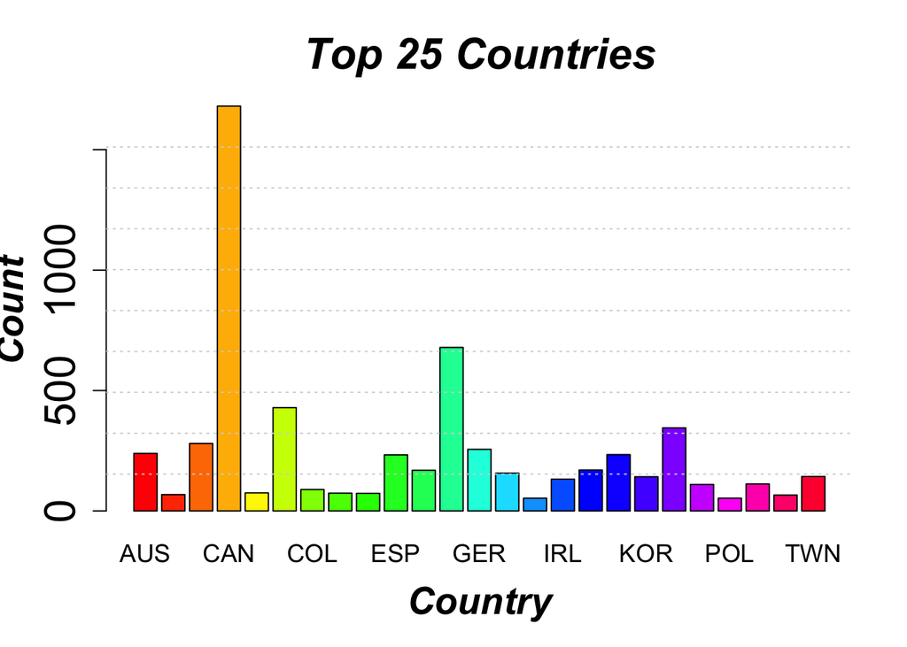

## Gender Distribution

*The gender distribution shows as predominantly male with a total of 14,670 vs. Females totaling: 11,981. The male to female ratio is: 1.22.*

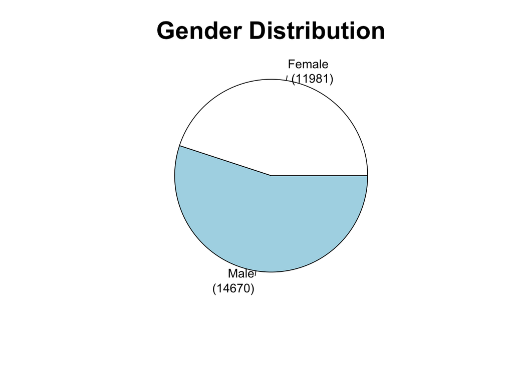

```
## [1] "Male / Female (ratio) = 14670 / 11981  =  1.22444"
```

## Central Limit Theorem

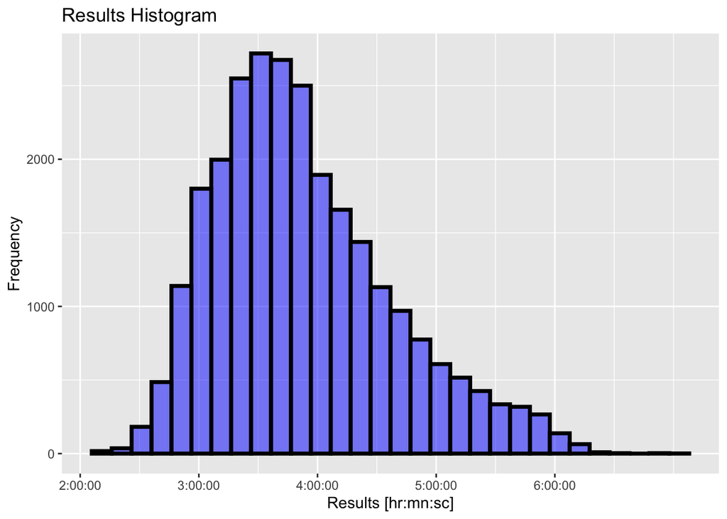

```
## [1] 54.5
```

```
## [1] 27.16616
```

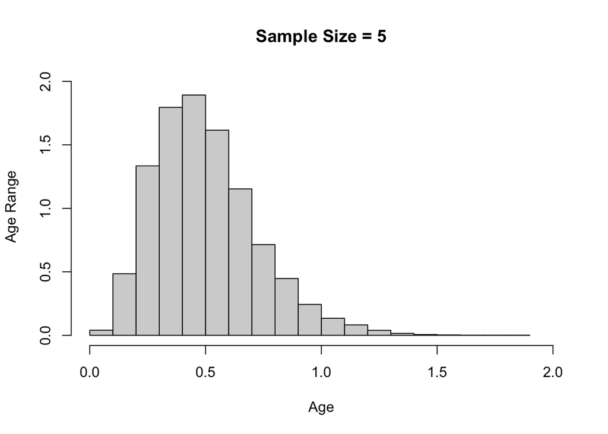

```
## [1] 54.5
```

```
## [1] 27.16616
```

```
## Sample Size =  15  Mean =  54.5  SD =  27.16616
```

```
## Sample Size =  20  Mean =  54.5  SD =  27.16616
```

```
## Sample Size =  25  Mean =  54.5  SD =  27.16616
```

```
## Sample Size =  30  Mean =  54.5  SD =  27.16616
```

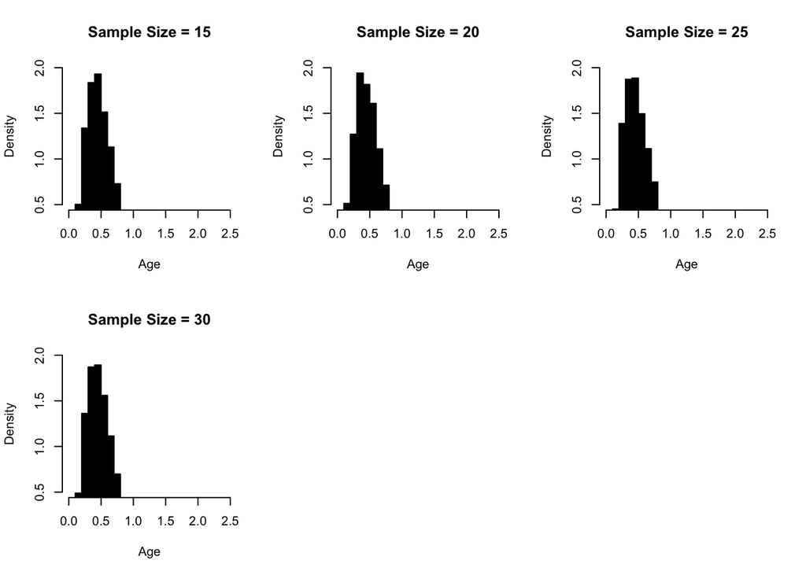

## Various Samples of Dataset

*Taking a look at different sample sets of the data, shows various results that could be useful for future marathons. For example, of the first 6 finishers, all were male, and 5 were from Kenya, with 2nd place being an Ethiopian male. This sample set may not reveal much overall, but is of interest that the top finishers were all male under 35, and all from Africa.*

*The next sample was a table of all ages. This table revealed total participants per age. For example, there were 32 aged 18, 2 runners were aged 83, and more than 1000 were 45 years old. This data sample is interesting as a table, because it is clear and concise of how many runners fell into a specific age.*

*Another sample set took a closer look at the head values of the results by hour. This led to taking a look at the top 5 (five) results with finishers coming in at around 2:07 to 2:08. The top 5 (five) results were then compared with the last (5) five finisher’s results. These results top the 6 hour mark at 6:21 to just shy of 7 hours.*

*As an end result, a scatterplot was done to show age vs. result by hour. The pink dots represent females, and blue dots are male. This plot is very interesting in that it shows the density of the results overall, with outliers of both genders at hour 5+.*

```
## [1] "Rank_Tot"     "Age"          "Gender"       "Country"      "Result_hr"
## [6] "Result_sec"   "Rank_Gender"  "Country_code" "Group"
```

|  | Rank_Tot | Age | Gender | Country | Rank_Gender |
| --- | --- | --- | --- | --- | --- |
| 1 | 1 | 30 | M | Kenya | 1 |
| 2 | 2 | 29 | M | Ethiopia | 2 |
| 3 | 3 | 34 | M | Kenya | 3 |
| 4 | 4 | 32 | M | Kenya | 4 |
| 5 | 5 | 26 | M | Kenya | 5 |
| 6 | 6 | 28 | M | Kenya | 6 |

```
##
##   18   19   20   21   22   23   24   25   26   27   28   29   30   31   32   33
##   32   39   54  122  218  301  408  466  573  576  630  628  616  595  623  553
##   34   35   36   37   38   39   40   41   42   43   44   45   46   47   48   49
##  568  789  714  777  761  708  925  808  776  671  648 1053  924  826  793  686
##   50   51   52   53   54   55   56   57   58   59   60   61   62   63   64   65
##  865  617  591  505  478  722  571  460  363  264  507  369  284  196  160  199
##   66   67   68   69   70   71   72   73   74   75   76   77   78   79   80   81
##  150  120   78   62   84   38   30   11    6   24   11   10    2    1    5    2
##   82   83
##    3    2
```

```
##
## FALSE  TRUE
## 19649  7002
```

```
##
## FALSE
## 26651
```

|  | Country |
| --- | --- |
| 26646 | United States |
| 26647 | United States |
| 26648 | United States |
| 26649 | United States |
| 26650 | United States |
| 26651 | United States |

|  | Age | Gender | Result_hr |
| --- | --- | --- | --- |
| 26646 | 33 | F | 6:18:13 |
| 26647 | 44 | F | 6:21:19 |
| 26648 | 50 | F | 6:22:27 |
| 26649 | 32 | F | 6:35:50 |
| 26650 | 55 | F | 6:53:38 |
| 26651 | 46 | F | 6:59:57 |

```
## [1] "2:07:57" "2:07:59" "2:08:07" "2:08:54" "2:08:55" "2:08:57"
```

```
## [1] "2:07:57" "2:07:59" "2:08:07" "2:08:54" "2:08:55"
```

```
## [1] "6:21:19" "6:22:27" "6:35:50" "6:53:38" "6:59:57"
```

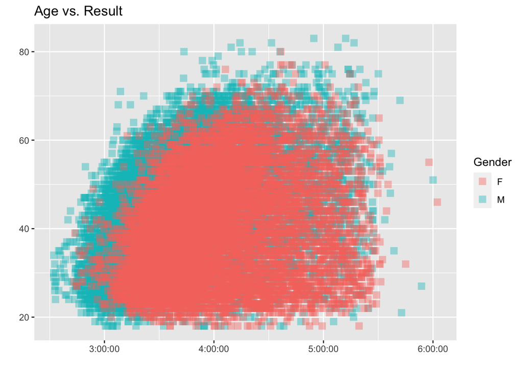

## Results Analysis

*Plotting the results by age group shows a strong pattern of longer finishing times with age group progression. However, as shown in the analysis above, age was not always the factor of finishing time.*

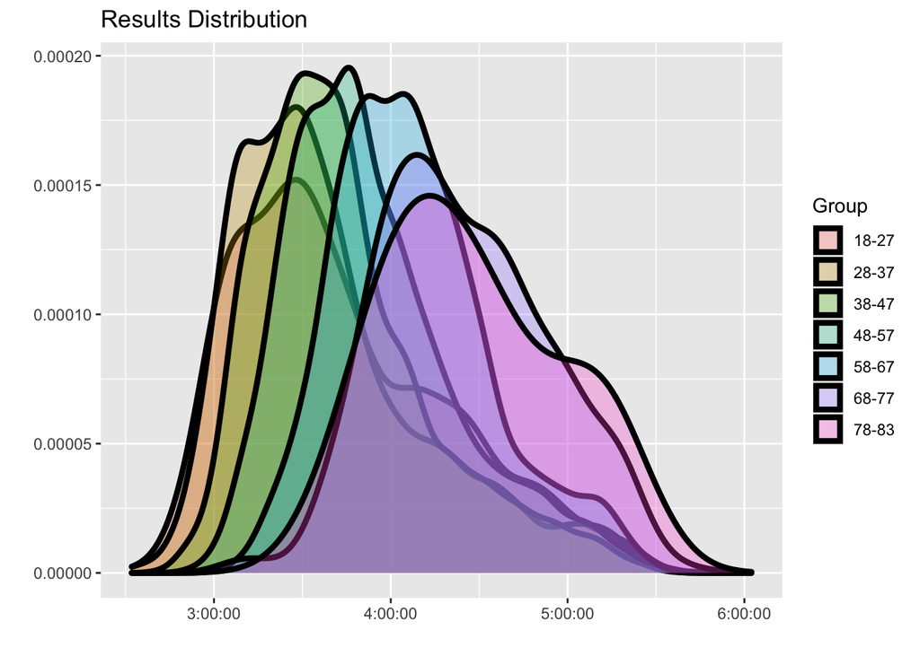

## Summary

*This analysis of the 2019 Boston Marathon dataset shows that males dominated this race in both overall gender and finishing time. Females hold the tail end of finishing times with over 6 hours, coming in just under 7 hours total. While the USA had the highest race participants, they did not lead in the top finishers of the race.*

[figure not shown]